# Module 31: ERM Implementation

C. Lau

September 28, 2016

## Module 31 Objective

Discuss the framework for risk management and control within a company

- Discuss how to adopt best practice in ERM in compliance and corporate governance

Focus on the process for implementing ERM successfully in an org

Themes in the module is similar to the prior modules, but in the **context of an org’s implementation**, over time, of an ERM framework

Adoption of ERM must not be thought of as a one off exercise

It should be treated as a **dynamic process**, which is regularly reviewed, updated in light of internal changes and changes in the external business environment and improved as best practice regarding thinking in ERM evolves

## Application of ERM to Business

### Implementation Project Management

#### Resourcing

Company needs to decided on resources for implementing ERM:

- **Internally**:

  Current staff with risk expertise and training further staff
- **Externally**:

  Use risk professional on a consulting basis
- **Both**:

  Calling upon consultants where the org faces gaps in knowledge or needs specialist advice

Implementation of ERM typically takes several years and requires a **risk champion** (i.e. senior exec who is willing to act as project sponsor)

- Sponsor will need to judge that the benefits of an ERM program (e.g. improved efficiency and reduced loss) will outweigh the costs

#### Proportionality and the Pareto Rule

*Proportionality*

- ERM framework appropriate to one org (e.g. small auto insurer) will not be appropriate for a different org (e.g. global composite insurer)
- One size **does not** fit all

*Pareto Rule*

- To ensure ERM adds value, RM activities need to feed through into action
- Decisions on which actions to take are taken based on the data, information and analysis provided to the org decisions makers
- 80% of the effort should be in data collection, analysis and reporting
- 20% to be in the decision making
- BUT **80% of the value** of ERM **is a result of informed decision making**

Company should ensure that its ERM framework is **commensurate** with the `risks it faces` and the `size/sophistication` of the business; e.g.

- Small retail chain facing simple specific risk will not necessarily need complex financial models and lots of resources applied to RM
- Large insurer selling a wide variety of products is likely to require sophisticated models, dedicated RM staff and extensive RM processes

#### Top Down / Bottom Up

*Different form* of ERM implementation

- **Bottom-up**:

  Data is collected and analyzed and fed up to decision makers
- **Top-down**:

  Decision-making structure and policies etc are established and the information gathering and analysis is configured to support it
- Lam suggests that top-down is most efficient and effective
- In practice will be a hybrid of both (e.g. a top down approach that is constrained by existing systems of data recording / analysis)

### Implementation Requirements

*Key questions* company should ask to ensure a successful ERM implementation

1. **Governance structure** and **politics**:

   Who is responsible for risk oversight and critical RM decisions?
2. **Risk assessment** and **quantification**:

   How (ex-ante) will they make these decisions?
3. **Risk management**:

   What decisions will they make to optimize the risk/return profile of the org
4. **Reporting** and **monitoring**:

   How (ex-post) will such decisions be monitored?

### Stage of Implementation

3 main *business applications* of RM (from Lam):

1. Loss reduction
2. Uncertainty management
3. Performance optimization

Business typically moves through these 3 stages as their RM capabilities mature

Overall combination of the 3 = ERM

#### 1. Loss Reduction

**First stage** of risk management: **protect against downside losses**

*5 types of controls* aimed at limiting downside losses:

1. **Credit controls**:

   Reduce the probability of default and maximize recovery
2. **Investment and liquidity policies**:

   Minimize portfolio losses and ensure liquidity, perhaps by adopting lower-risk investment policies
3. **Other internal control**:

   Reduce the probability and severity of op-losses
4. **Audit** process:

   Ensure the finances of the company are in order
5. **Insurance coverage**:

   Transfer risk to 3<sup>rd</sup> parties

`Loss reduction` is **necessary** but **not sufficient** for ERM

#### 2. Uncertainty Management

RM can help support a business’s `profitability` and `business objectives` more positively

Sources and degree of volatility have increased greatly in recent decades while business are under pressure from their investors to reduce earnings volatility

*5 improved practices* over loss control that may help to manage the increased volatility

1. **Credit model**:

   Better understand credit risk, predict and make provision for losses
2. **Market risk measurement** and **management techniques**:

   Simulation models and measurement tools, including VaR and economic capital
3. Increased **mangement of op-risk**

   Particularly `crisis management` and `prevention`
4. Improved **corporate governance policies**
5. **Wider application of risk transfer**:

   Use `derivatives` and `sophisticated insurance products` including `ART`

Overall these developments improve the business’s ability to view and understand its risks and return more **holistically** to the benefit of investors

#### 3. Performance Optimization

Final stage is to take a more **integrated** approach to risk management and to bring risk management into the **business’s decision making** (e.g. product pricing strategic capital investment decisions and budgeting)

1. **Active management** of its `credit risk portfolio`:

   Pricing for risk and disaggregating (breakdown) its credit business into distinct activities
2. **Active management** of its `balance sheet`:

   Considering all assets and liabilities (not just in the investment portfolio) with a view to **optimzing** risk/reward trade off
3. **Re-engineering** of `processes` to minimize op-risk and to better understand and reduce costs

For financial companies, such activities are expected by regulators

### Challenges to Implementation

#### Promoting Risk Awareness

Successful strategies from improving risk awareness include:

1. Set the **tone form the top**
   - Critical that the CEO act as a role model by displaying the desired behaviors
2. **Ask the right questions** concerning risk
   - **Risk/return balance**
   - `Limits` and other `controls` to **minimize the downside risk**
   - **Systems**
   - **Knowledge**
3. Establish a common **risk taxonomy**

   Common language and risk classification structure ensures consistent measurement and facilitates aggregation when reporting
4. Provide **induction training** and **ongoing education**
5. **Link compensation** to `risk` to reward desired behaviors

#### Implementing culture change

Culture can only be changed effectively:

- **From the top** of the organization (i.e. led by the Board and sr management)
- On an **incremental** basis
- As the profile of **new recruits** changes the view of the staff

## ERM Maturity Models

Many version of ERM maturity models promoted by consultancies but there is no one right model

- We considered the evolution of RM practice from basic to best practice for market, credit and op-risk
- External stakeholders (rating agencies, regulators) also have a view on how sophisticated a company’s ERM capabilities are

### Lam’s 5 Stage ERM Maturity Model

1. **Definition** and **planning**

   Consists of organizing resources to define and scope an ERM program
   - Identify `internal` and `external` **requirements** for the ERM program
   - Obtaining Board and management **support**
   - Developing **overall framework** and **plan**
   - Appointing **key personnel**
2. **Early development**

   Consists of **formalizing** `roles and reponsibilities`, `identifying risks` and `education`
   - Establishing **ERM policies** and **risk functions**
   - Identifying **key risks**
   - **Co-ordinating** `risk` and `control processes` across the functions
   - **Educating** and **training** (esp. for the board)
3. **Standard practice**

   Consist of improving risk assessment capabilities and developing risk quanitification processes
   - Establishing **risk database** for events and losses
   - Developing **KRIs**
   - Establishing **risk models** for market, credit and op-risk
   - **Measuring** risk-adjusted performance
4. **Business integration**

   Consists of intergrating ERM into business management, operations and remuneration
   - Evaluating **business risk**
   - Quantifying the **cost of risk** to support pricing and risk transfer decisions
   - *Automating* **risk reporting**
   - **Allocating** capital according to risk
   - Using **risk triggers** to prompt business decisions
   - *Measuring* the **effectiveness** of ERM processes and **linking** to executive *remuneration*
5. **Business optimization**

   Consist of optimizing business performance, integrating ERM into strategy development and enhancing relationships with key stakeholders
   - Expanding the scope of ERM to include **strategic risk**
   - **Integrating** ERM into strategic planning processes

   **Allocating capital** and **resources** to optimize risk-adjusted performance

### McKinsey 4-Stage Risk Maturity Model

This model focused more on outputs/benefits than on actions/processes

1. **Initial risk transparency**:
   - Compliance with basic standards
   - Reduction of regular surprises
2. **Systemic loss reduction**:
   - Ability to avoid large losses
   - Stability to enable growth plan
   - Professionalized management
3. **Risk-return management**:
   - Improved return on equity
   - Becoming competitive with industry standards
4. **Risk as competitive advantage**:
   - Senior management focused on risk-adjusted performance

### Deloitte 5-Stage Risk Maturity Model

1. **Unaware/planning**:
   - Ad-hoc / chaotic risk management
   - Depend primarily on individual capabilities
2. **Fragmented/specialist silos**:
   - Reaction to adverse events by specialists
   - Discrete roles established for small set of risks
   - Basic regulatory compliance
3. **Top-down**: Tone set at the top
   - Policies, procedures, risk authorities defined and communicated
   - Measurement is primarily qualitative, reactive risk management
4. **Systematic**:
   - Co-ordinated risk management across silos
   - Integrated responses to adverse events, rapid escalation
   - Risk culture transformation underway
5. **Risk intelligent**:
   - Risk management is everyone’s job
   - ERM process is built into decision making using performance-linked metrics

### IAA Stages of ERM Maturity

1. **Early**

   RM and internal control activities **exist in part**
   - Inconsistently applied
   - Not well understood by management and the relevant employees in **limited** business areas
   - Significant opportunities for enhancement remain
2. **Intermediate**

   RM and internal control activities are **established**
   - Not consistently applied
   - Not fully understood by management and relevant employees in **key functions**/business area
   - Moderate opportunities for enhancement remain
3. **Advanced**

   RM and internal control activities are **established**
   - Consistently applied
   - Well understood by management and relevant employees across the organization
   - Opportunities for enhancement remain to align and coordinate activity across the organization

Appendix 2 of IAA note contains a table[^1] describing a risk management maturity model

- Has more detail on the above 3 stages broken down by area: `role of the Board`, `RM policy`, `management accountability`, `reporting` and `monitoring`

*Key questions to consider* when assessing the maturity of and ERM framework

- **The Board**:

  Role?
- **Risk appetite**:

  How well is it defined, reviewed and communicated?
- **RM policy**:

  How comprehensive is it?
- **Management accountabilities**:

  How clearly are they defined?
- **Management commitment and leadership**:

  How committed is the management to ERM?
- **RMF**:

  What responsibilities and resources does it have?
- **Risk language**:

  How well developed and documented is it?
- **Risk management culture**:

  How well developed is it?
- **Performance management and reward systems**:

  How well aligned with ERM are they?
- **Risk and solvency assessments**:

  How sophisticated are they?
- **Risk management processes**:

  How comprehensive are they?
- **Reporting and monitoring process and systems**:

  How comprehensive are they?
- **Internal audit of compliance with RM policy**:

  How comprehensive is it?
- **New activities**:

  What extent are risk management techniques applied?
- **Business continuity plans / analysis**:

  How comprehensive are they?

### Implementation case studies

Appendix 3 of IAA describes some examples of ERM programs in various business

- Successful implementation of an ERM strategy involving building a capital model in a large insurer
- Cautionary tale of an over-engineered ERM project in a large insurer
- Apparently successful ERM project in a global insurer, but one where success was measured by the quality of the process, not the quality of the impact on business outcomes
[^1]: *Stages of Enterprise Risk Management Maturity*

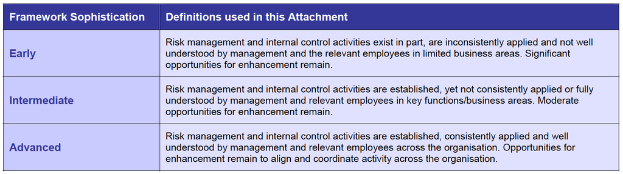

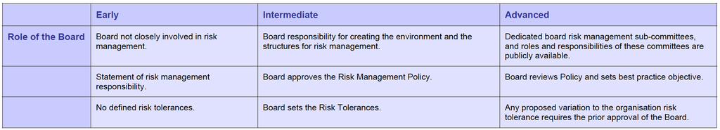

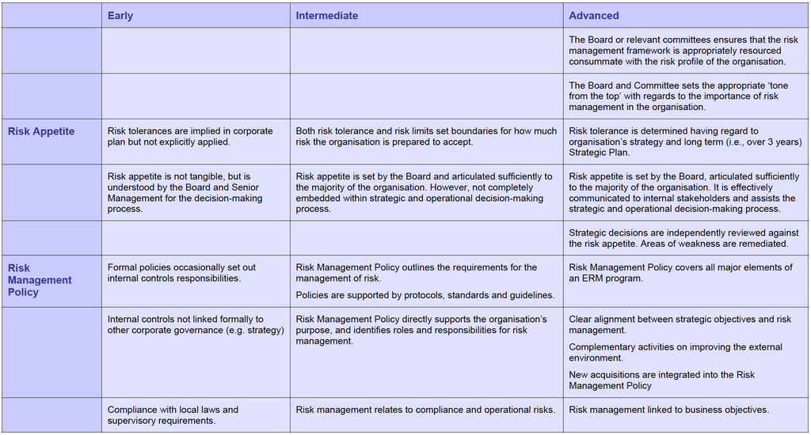

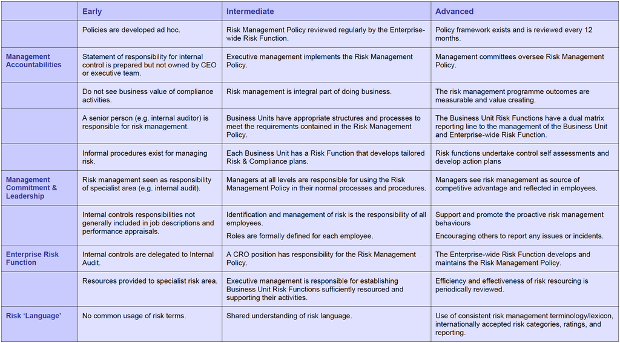

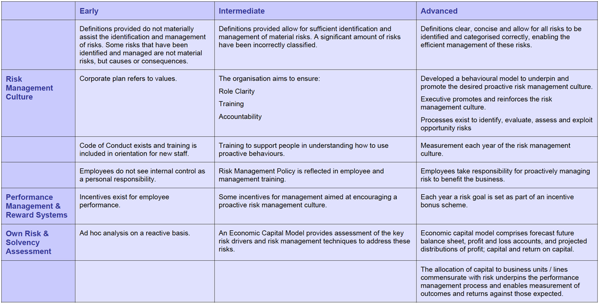

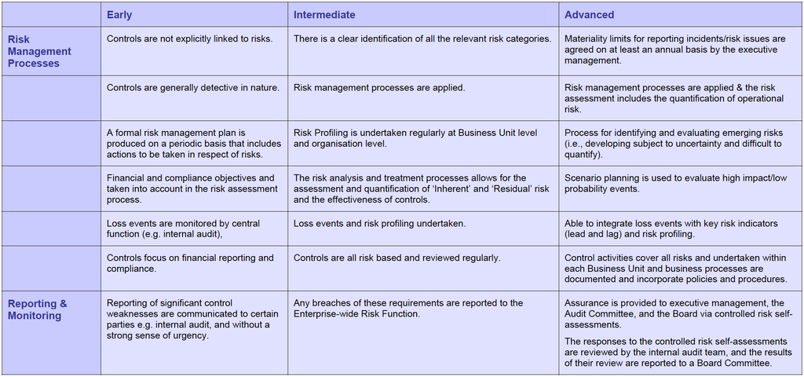

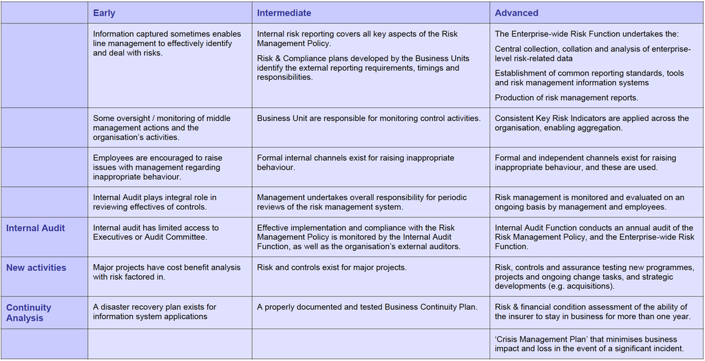